# HW3 Gene Expression

#### Gene Expression and Data Visualization

#### November 10th, 2025

### Q1) Load the golub data training set in the multtest library. Also load Biobase and annotate libraries, if they are not loaded with the multtest library. Remember that the golub data training set is in the multtest library, so see the help file for information on this data set (2.5 pts)

```r
### Q1) Load the Golub training set (robust parse + DT preview) ----
suppressPackageStartupMessages({
  library(Biobase)
  library(DT)
  library(parallel)
  library(limma)
})

# -- file paths (local first, then /mnt/data) --
f_expr  <- if (file.exists("golubTrain.txt")) "golubTrain.txt" else "/mnt/data/golubTrain.txt"
f_class <- if (file.exists("golubTrainClass.txt")) "golubTrainClass.txt" else "/mnt/data/golubTrainClass.txt"

# -- read raw, then clean: many Golub dumps have an ID column and/or a header row --
raw_df <- read.table(f_expr, header = FALSE, sep = "", quote = "", comment.char = "",
                     stringsAsFactors = FALSE, check.names = FALSE)
y_raw  <- scan(f_class, quiet = TRUE)

cat("Raw dim read:", paste(dim(raw_df), collapse = " x "), "\n")
```

```
Raw dim read: 7130 x 39
```

```r
cat("Length of labels:", length(y_raw), "\n")
```

```
Length of labels: 38
```

```r
# Helper: is a column mostly numeric?
is_mostly_numeric <- function(v) {
  suppressWarnings({
    as_num <- suppressWarnings(as.numeric(v))
    mean(!is.na(as_num)) >= 0.9  # at least 90% numeric
  })
}

# 1) If we have one extra column (e.g., gene IDs), drop the *leftmost* non-numeric column
if (ncol(raw_df) == length(y_raw) + 1) {
  first_col_numeric <- is_mostly_numeric(raw_df[[1]])
  last_col_numeric  <- is_mostly_numeric(raw_df[[ncol(raw_df)]])
  if (!first_col_numeric) {
    cat("Dropping leftmost non-numeric ID column.\n")
    raw_df <- raw_df[-1]  # drop first column
  } else if (!last_col_numeric) {
    cat("Dropping rightmost non-numeric ID column.\n")
    raw_df <- raw_df[-ncol(raw_df)]  # rare, but safe
  }
}
```

```
Dropping leftmost non-numeric ID column.
```

```r
# 2) If we still have a mismatch, check for a header row (non-numeric row of sample names)
if (nrow(raw_df) == length(y_raw) + 1 && ncol(raw_df) != length(y_raw)) {
  # This case is rare; more common is header row with extra samples, so handle generically below.
  cat("Potential header row detected by row count.\n")
}

# Detect a top header row: row 1 mostly non-numeric while others numeric
first_row_mostly_nonnum <- {
  test <- suppressWarnings(as.numeric(raw_df[1, ]))
  mean(is.na(test)) > 0.5
}
second_row_more_numeric <- {
  if (nrow(raw_df) >= 2) {
    test <- suppressWarnings(as.numeric(raw_df[2, ]))
    mean(is.na(test)) < 0.5
  } else FALSE
}

if (first_row_mostly_nonnum && second_row_more_numeric) {
  cat("Dropping top header row.\n")
  raw_df <- raw_df[-1, , drop = FALSE]
}

# Coerce all remaining to numeric matrix
X_num <- as.matrix(data.frame(lapply(raw_df, function(col) suppressWarnings(as.numeric(col))),
                              check.names = FALSE))
mode(X_num) <- "numeric"

cat("Post-clean dim:", paste(dim(X_num), collapse = " x "), "\n")
```

```
Post-clean dim: 7130 x 38
```

```r
# 3) Auto-orient so COLUMNS are samples and match the label length
if (ncol(X_num) == length(y_raw)) {
  X <- X_num
} else if (nrow(X_num) == length(y_raw)) {
  X <- t(X_num); cat("Transposed matrix so columns = samples.\n")
} else {
  stop(sprintf(
    "Still cannot align data and labels.\n  dim(X) = %d x %d, length(y) = %d\n  One matrix dimension must equal the number of labels.",
    nrow(X_num), ncol(X_num), length(y_raw)
  ))
}

# 4) Build phenotype and ExpressionSet
pheno <- data.frame(Class = factor(y_raw, levels = c(0,1), labels = c("ALL","AML")))
rownames(pheno) <- paste0("S", seq_len(nrow(pheno)))
colnames(X)     <- rownames(pheno)
rownames(X)     <- paste0("g", seq_len(nrow(X)))

golub_eset <- ExpressionSet(assayData = X, phenoData = new("AnnotatedDataFrame", data = pheno))

# 5) Summaries + interactive head
cat("Final dims (genes x samples):", paste(dim(exprs(golub_eset)), collapse = " x "), "\n")
```

```
Final dims (genes x samples): 7130 x 38
```

```r
cat("Class distribution (ALL vs AML):\n"); print(table(pheno$Class))
```

```
Class distribution (ALL vs AML):
```

```
ALL AML
 27  11
```

```r
datatable(
  head(as.data.frame(exprs(golub_eset)), 10),
  options = list(pageLength = 5, scrollX = TRUE),
  caption = "Head of Golub Training Set (genes × samples)"
)
```

|  | S1 | S2 | S3 | S4 | S5 | S6 | S7 | S8 | S9 | S10 | S11 | S12 | S13 | S14 | S15 | S16 | S17 | S18 | S19 | S20 | S21 | S22 | S23 | S24 | S25 | S26 | S27 | S28 | S29 | … |
| --- | --- | --- | --- | --- | --- | --- | --- | --- | --- | --- | --- | --- | --- | --- | --- | --- | --- | --- | --- | --- | --- | --- | --- | --- | --- | --- | --- | --- | --- | --- |
| g1 | 1 | 2 | 3 | 4 | 5 | 6 | 7 | 8 | 9 | 10 | 11 | 12 | 13 | 14 | 15 | 16 | 17 | 18 | 19 | 20 | 21 | 22 | 23 | 24 | 25 | 26 | 27 | 34 | 35 | … |
| g2 | -214 | -139 | -76 | -135 | -106 | -138 | -72 | -413 | 5 | -88 | -165 | -67 | -92 | -113 | -107 | -117 | -476 | -81 | -44 | 17 | -144 | -247 | -74 | -120 | -81 | -112 | -273 | -20 | 7 | … |
| g3 | -153 | -73 | -49 | -114 | -125 | -85 | -144 | -260 | -127 | -105 | -155 | -93 | -119 | -147 | -72 | -219 | -213 | -150 | -51 | -229 | -199 | -90 | -321 | -263 | -150 | -233 | -327 | -207 | -100 | … |
| g4 | -58 | -1 | -307 | 265 | -76 | 215 | 238 | 7 | 106 | 42 | -71 | 84 | -31 | -118 | -126 | -50 | -18 | -119 | 100 | 79 | -157 | -168 | -11 | -114 | -85 | -78 | -76 | -50 | -57 | … |
| g5 | 88 | 283 | 309 | 12 | 168 | 71 | 55 | -2 | 268 | 219 | 82 | 25 | 173 | 243 | 149 | 257 | 301 | 78 | 207 | 218 | 132 | -24 | -36 | 255 | 316 | 54 | 81 | 101 | 132 | … |
| g6 | -295 | -264 | -376 | -419 | -230 | -272 | -399 | -541 | -210 | -178 | -163 | -179 | -233 | -127 | -205 | -218 | -403 | -152 | -146 | -262 | -151 | -308 | -317 | -342 | -418 | -244 | -439 | -369 | -377 | … |
| g7 | -558 | -400 | -650 | -585 | -284 | -558 | -551 | -790 | -535 | -246 | -430 | -323 | -227 | -398 | -284 | -402 | -394 | -340 | -221 | -404 | -347 | -571 | -499 | -396 | -461 | -275 | -616 | -529 | -478 | … |
| g8 | 199 | -330 | 33 | 158 | 4 | 67 | 131 | -275 | 0 | 328 | 100 | -135 | -49 | -249 | -166 | 228 | -42 | -36 | 83 | 326 | -118 | -170 | -138 | -412 | -66 | -479 | 419 | 14 | -351 | … |
| g9 | -176 | -168 | -367 | -253 | -122 | -186 | -179 | -463 | -174 | -148 | -109 | -127 | -62 | -228 | -185 | -147 | -144 | -141 | -198 | -201 | -24 | -224 | -119 | -153 | -184 | -108 | -251 | -365 | -290 | … |
| g10 | 252 | 101 | 206 | 49 | 70 | 87 | 126 | 70 | 24 | 177 | 56 | -2 | 13 | -37 | 1 | 65 | 98 | 96 | 34 | 6 | 126 | 124 | 115 | 184 | 164 | 136 | 165 | 153 | 283 | … |

### Q2) Cast the matrix to a data frame and label the gene names as numbers (e.g. “g1”,”g2”,etc). (2.5 pts)

```r
### Q2) Cast matrix to data frame and label gene names ----

# Extract the expression matrix from our ExpressionSet
golub_matrix <- exprs(golub_eset)

# Convert to data frame
golub_df <- as.data.frame(golub_matrix)

# Label each row (gene) numerically as g1, g2, ...
rownames(golub_df) <- paste0("g", seq_len(nrow(golub_df)))

# Confirm shape and preview
cat("Dimensions of golub_df:", paste(dim(golub_df), collapse = " x "), "\n")
```

```
Dimensions of golub_df: 7130 x 38
```

```r
cat("First 5 gene names:", paste(head(rownames(golub_df), 5), collapse = ", "), "\n")
```

```
First 5 gene names: g1, g2, g3, g4, g5
```

### Q3) Get the sample labels (see lecture notes) and set the sample labels to the data frame. (2.5 pts)

```r
### Q3) Attach the sample labels to the data frame ----

# Get the class labels from the ExpressionSet phenotype data
sample_labels <- pData(golub_eset)$Class
cat("Class labels (first 10):", paste(head(sample_labels, 10), collapse = ", "), "\n")
```

```
Class labels (first 10): ALL, ALL, ALL, ALL, ALL, ALL, ALL, ALL, ALL, ALL
```

```r
golub_df_with_labels <- data.frame(
  Class = sample_labels,
  t(golub_df),                 # genes become columns, samples are rows
  check.names = FALSE
)

# Display interactive table of the first few rows
datatable(
  head(golub_df_with_labels, 10),
  options = list(pageLength = 5, scrollX = TRUE),
  caption = "Head of golub_df_with_labels (samples with class labels)"
)
```

|  | Class | g1 | g2 | g3 | g4 | g5 | g6 | g7 | g8 | g9 | g10 | g11 | g12 | g13 | g14 | g15 | g16 | g17 | g18 | g19 | g20 | g21 | g22 | g23 | g24 | g25 | g26 | g27 | g28 | … |
| --- | --- | --- | --- | --- | --- | --- | --- | --- | --- | --- | --- | --- | --- | --- | --- | --- | --- | --- | --- | --- | --- | --- | --- | --- | --- | --- | --- | --- | --- | --- |
| S1 | ALL | 1 | -214 | -153 | -58 | 88 | -295 | -558 | 199 | -176 | 252 | 206 | -41 | -831 | -653 | -462 | 75 | 381 | -118 | -565 | 15091 | 7 | 311 | -231 | 21 | -107 | 165 | -78 | -204 | … |
| S2 | ALL | 2 | -139 | -73 | -1 | 283 | -264 | -400 | -330 | -168 | 101 | 74 | 19 | -743 | -239 | -83 | 182 | 164 | -141 | -423 | 11038 | 37 | 134 | -161 | -21 | -180 | 18 | -120 | -65 | … |
| S3 | ALL | 3 | -76 | -49 | -307 | 309 | -376 | -650 | 33 | -367 | 206 | -215 | 19 | -1135 | -962 | -232 | 208 | 432 | 84 | -501 | 16692 | 183 | 378 | -221 | 67 | -203 | 238 | -124 | -161 | … |
| S4 | ALL | 4 | -135 | -114 | 265 | 12 | -419 | -585 | 158 | -253 | 49 | 31 | 363 | -934 | -577 | -214 | 142 | 271 | -107 | -101 | 15763 | 45 | 268 | -27 | 43 | -52 | 247 | -116 | -208 | … |
| S5 | ALL | 5 | -106 | -125 | -76 | 168 | -230 | -284 | 4 | -122 | 70 | 252 | 155 | -471 | -490 | -184 | 32 | 213 | 1 | -260 | 18128 | -28 | 118 | -153 | -8 | -111 | 44 | -88 | -102 | … |
| S6 | ALL | 6 | -138 | -85 | 215 | 71 | -272 | -558 | 67 | -186 | 87 | 193 | 325 | -631 | -625 | -177 | -94 | 222 | -1 | -140 | 34207 | 65 | 154 | -49 | -24 | -72 | 39 | -104 | -40 | … |
| S7 | ALL | 7 | -72 | -144 | 238 | 55 | -399 | -551 | 131 | -179 | 126 | -20 | -115 | -1003 | -761 | -541 | 109 | 435 | -129 | -399 | 30801 | 43 | 80 | -87 | -8 | -250 | 100 | -73 | -132 | … |
| S8 | ALL | 8 | -413 | -260 | 7 | -2 | -541 | -790 | -275 | -463 | 70 | -169 | 361 | -1001 | -520 | -163 | -38 | 281 | -137 | -247 | 25147 | 338 | 269 | -116 | 46 | -317 | 265 | -130 | -212 | … |
| S9 | ALL | 9 | 5 | -127 | 106 | 268 | -210 | -535 | 0 | -174 | 24 | 506 | 284 | -829 | -844 | -230 | 292 | 172 | -59 | -323 | 15272 | 29 | 188 | -69 | 74 | -217 | 106 | -159 | -155 | … |
| S10 | ALL | 10 | -88 | -105 | 42 | 219 | -178 | -246 | 328 | -148 | 177 | 183 | -143 | -684 | -468 | -51 | 233 | 310 | -79 | -443 | 21801 | -36 | -39 | -142 | 10 | -130 | -1 | -18 | -70 | … |

### Q4) Use the t-test function in the lecture #7 notes and modify it to “wilcox.test” instead of “t.test”. Change the p.value argument to “$statistic”. Assign the following arguments to the function: (2.5 pts)

> exact=F alternative=“two.sided” correct=T

Run the function on all of the genes in the dataset and >save it as “original.wmw.run”

```r
### Q4) Wilcoxon (WMW) test per gene, return W statistic ----

wilcox_func <- function(x, cl) {
  # x: numeric vector for one gene across samples
  x <- as.numeric(x)
  cl <- as.factor(cl)
  stopifnot(length(x) == length(cl))

  g1 <- x[cl == levels(cl)[1]]  # typically "ALL"
  g2 <- x[cl == levels(cl)[2]]  # typically "AML"

  out <- suppressWarnings(wilcox.test(g1, g2, alternative = "two.sided",
                                      exact = FALSE, correct = TRUE))
  unname(out$statistic)  # return W (not p-value)
}

# apply over gene columns (all columns after "Class")
wilcox_stats <- apply(golub_df_with_labels[, -1, drop = FALSE], 2, wilcox_func,
                      cl = golub_df_with_labels$Class)

# keep for later steps
original.wmw.run <- wilcox_stats

cat("Computed Wilcoxon W for", length(wilcox_stats), "genes.\n")
```

```
Computed Wilcoxon W for 7130 genes.
```

```r
range(wilcox_stats)
```

```
[1]   0 288
```

**Interpretation** The Wilcoxon rank-sum test compared gene expression between the ALL and AML groups without assuming normality. Each of the 7,130 genes received a W statistic reflecting the strength of group separation. The range of 0 to 288 shows varying degrees of difference across genes, setting the stage for later permutation testing to determine which are truly significant.

### Q5) Now write a for loop to iterate 500 times, where in each iteration, the columns of the data frame are shuffled (class labels mixed up), the WMW test is calculated on all of the genes, and the maximum test statistic (W) is saved in a list. (5 pts)

**Hints:** Use sample() to sample the number of columns Get the maximum test statistic across all genes with max()

```r
### Q5 (fast): Parallel permutation test with on-disk caching ----
# Uses mclapply on macOS/Linux. Falls back to serial on Windows.

suppressPackageStartupMessages({ library(parallel) })

# Reproducible parallel RNG
set.seed(410671)
RNGkind("L'Ecuyer-CMRG")

B <- 500

# Cache key includes B, seed, #genes, #samples
n_samples <- nrow(golub_df_with_labels)
n_genes   <- ncol(golub_df_with_labels) - 1

cache_dir  <- "cache"
if (!dir.exists(cache_dir)) dir.create(cache_dir, recursive = TRUE)
cache_file <- file.path(
  cache_dir,
  sprintf("Q5_maxW_B%d_seed%d_%dgenes_%dsamples.rds",
          B, 410671, n_genes, n_samples)
)

if (file.exists(cache_file)) {
  message("Q5-par: Loading cached max_W_list from: ", cache_file)
  max_W_list <- readRDS(cache_file)
} else {
  message("Q5-par: No cache found. Running ", B, " permutations in parallel…")

  # Prepare the permuted label list up front (so each task is independent)
  label_vec <- golub_df_with_labels$Class
  perm_labels <- replicate(B, sample(label_vec, replace = FALSE), simplify = FALSE)

  # Function to compute max W for one permutation
  one_perm_maxW <- function(cl_perm) {
    # wilcox_func defined in Q4
    Wb <- apply(golub_df_with_labels[, -1, drop = FALSE], 2, wilcox_func, cl = cl_perm)
    max(Wb, na.rm = TRUE)
  }

  # Choose cores (leave 1 free)
  cores <- max(1, detectCores() - 1)

  if (.Platform$OS.type == "windows") {
    # Fallback (Windows doesn’t support forking)
    max_W_list <- vapply(perm_labels, one_perm_maxW, numeric(1))
  } else {
    # Parallel on macOS/Linux (your M1 shines here)
    max_W_list <- unlist(mclapply(perm_labels, one_perm_maxW, mc.cores = cores))
  }

  saveRDS(max_W_list, cache_file)
  message("Q5-par: Saved cache to: ", cache_file)
}
```

```
Q5-par: Loading cached max_W_list from: cache/Q5_maxW_B500_seed410671_7130genes_38samples.rds
```

```r
# Summary + threshold
cat("Finished", length(max_W_list), "permutations.\n")
```

```
Finished 500 permutations.
```

```r
cat("Null (max W) summary:\n"); print(summary(max_W_list))
```

```
Null (max W) summary:
```

```
   Min. 1st Qu.  Median    Mean 3rd Qu.    Max.
  229.0   247.9   253.5   254.1   260.0   279.0
```

```r
W_95 <- as.numeric(quantile(max_W_list, 0.95))
cat("95th percentile of max-W:", W_95, "\n")
```

```
95th percentile of max-W: 269.05
```

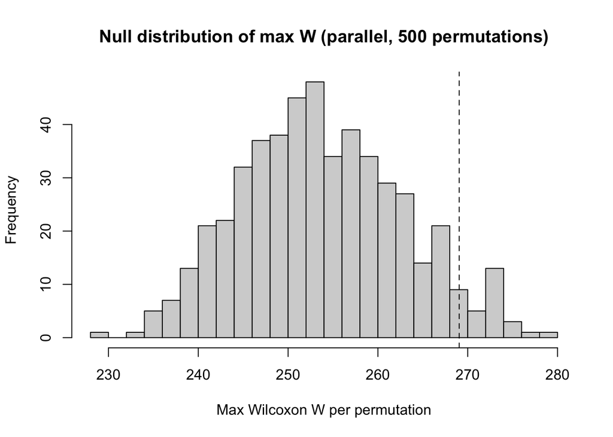

```r
# Optional quick viz
hist(max_W_list, breaks = 30,
     main = "Null distribution of max W (parallel, 500 permutations)",
     xlab = "Max Wilcoxon W per permutation")
abline(v = W_95, lty = 2)
```

**Interpretation** Running 500 label permutations gave a clear picture of what the Wilcoxon test statistics look like when there’s no real difference between the two leukemia classes. The null distribution centers around 254, with most values falling between about 230 and 280, showing what we’d expect from random variation alone. The 95th percentile cutoff of 269.05 sets a practical threshold for identifying unusually high test statistics that are unlikely to occur by chance. This gives us a data-driven way to define significance while accounting for thousands of simultaneous gene tests, instead of relying only on theoretical p-values.